# MUSA 508 - Targeting A Housing Subsidy in Emil City

Ling Chen

2023/11/2

# Introduction

Emil City is considering a more proactive approach for targeting home owners who qualify for a home repair tax credit program. The Department of Housing and Community Development (HCD) tries to proactively reach out to eligible homeowners ever year, the uptake of the credit is woefully inadequate. Therefore, in this project, I’ll convert the client-level data collected from previous campaigns into a decision-making analytic that can better target their limited outreach resources. By running some logistic regression models, my goal is to train the best classifier and inform a cost/benefit analysis.

The data is adopted from Moro & Rita (2014).

# Data Exploration

## Data Visualization

Among the continuous variables, individuals who choose to take the credit tend to be contacted before and are slightly older on average. Additionally, many of them experience periods when the employment rate decreases over a quarter compared to the previous quarter. Furthermore, they exhibit a more moderate consumer price index and confidence index in comparison to those who do not take the credit. Simultaneously, they allocate fewer resources to home repairs.

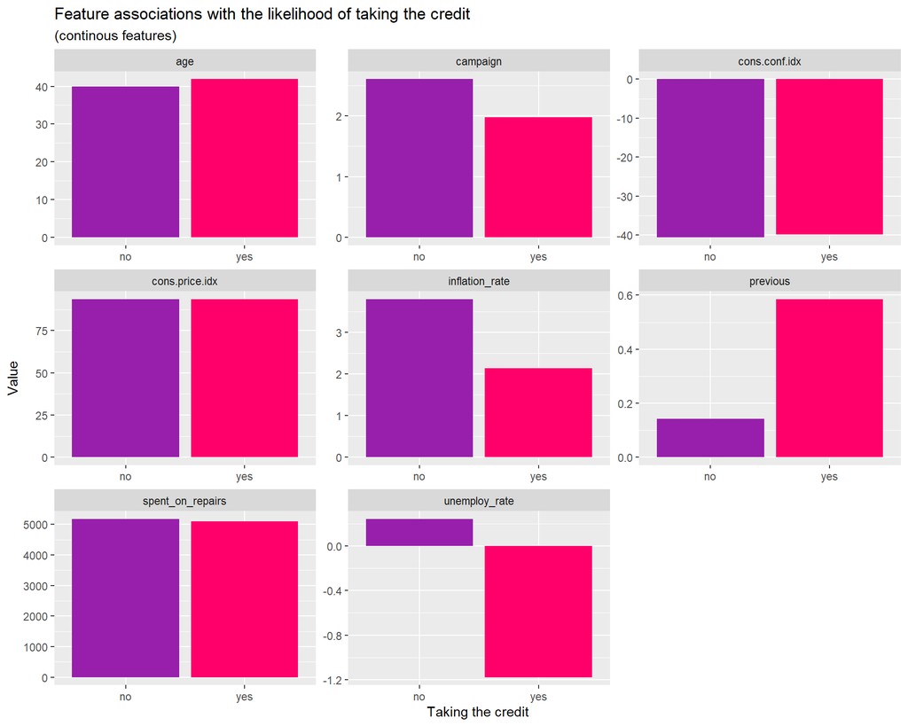

```r
housingSubsidy %>%
  dplyr::select(y, age, campaign, previous, unemploy_rate, cons.price.idx, cons.conf.idx, spent_on_repairs, inflation_rate) %>%
  gather(Variable, value, -y) %>%
    ggplot(aes(y, value, fill=y)) +
      geom_bar(position = "dodge", stat = "summary", fun = "mean") +
      facet_wrap(~Variable, scales = "free") +
      scale_fill_manual(values = palette2) +
      labs(x="Taking the credit", y="Value",
           title = "Feature associations with the likelihood of taking the credit",
           subtitle = "(continous features)") +
      theme(legend.position = "none")
```

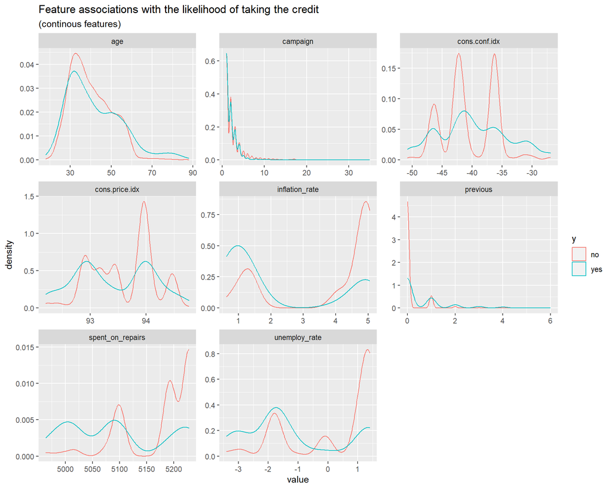

```r
housingSubsidy %>%
    dplyr::select(y, age, campaign, previous, unemploy_rate, cons.price.idx, cons.conf.idx, spent_on_repairs, inflation_rate) %>%
    gather(Variable, value, -y) %>%
    ggplot() +
    geom_density(aes(value, color=y), fill = "transparent") +
    facet_wrap(~Variable, scales = "free") +
    scale_fill_manual(values = palette2) +
      labs(title = "Feature associations with the likelihood of taking the credit",
           subtitle = "(continous features)")
```

```r
      #theme(legend.position = "none")
```

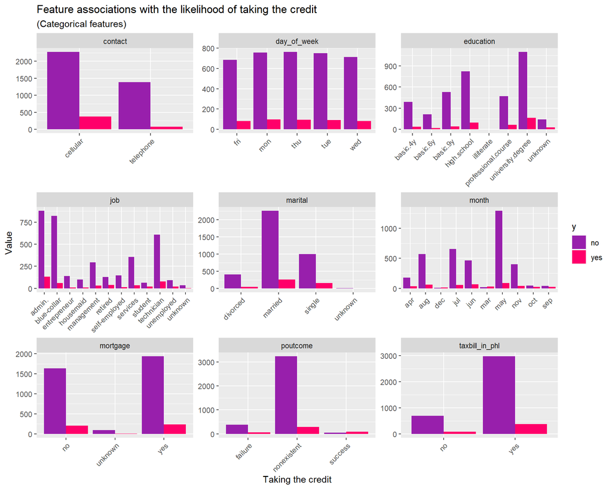

```r
housingSubsidy %>%
    dplyr::select(y, job, marital, education, mortgage, contact, month, day_of_week, poutcome, taxbill_in_phl) %>%
    gather(Variable, value, -y) %>%
    count(Variable, value, y) %>%
      ggplot(., aes(value, n, fill = y)) +
        geom_bar(position = "dodge", stat="identity") +
        facet_wrap(~Variable, scales="free") +
        scale_fill_manual(values = palette2) +
        labs(x="Taking the credit", y="Value",
           title = "Feature associations with the likelihood of taking the credit",
           subtitle = "(Categorical features)") +
        theme(axis.text.x = element_text(angle = 45, hjust = 1))
```

## Logistic Regression Initial Model

A logistic regression model predicts a binary outcome - a `1` or a `0` - a `taking the credit` or a `Not taking the credit`. I partition the data into a 65/35 training and test set.The first model includes all the variables.

```r
housingSubsidyModel <- glm(y_numeric ~ .,
                  data=housingSubsidyTrain %>%
                    dplyr::select(-X, -y),
                  family="binomial" (link="logit"))

summary(housingSubsidyModel)
```

```
##
## Call:
## glm(formula = y_numeric ~ ., family = binomial(link = "logit"),
##     data = housingSubsidyTrain %>% dplyr::select(-X, -y))
##
## Coefficients:
##                                 Estimate  Std. Error z value Pr(>|z|)
## (Intercept)                  -64.6972440 131.6291709  -0.492   0.6231
## age                            0.0039217   0.0085356   0.459   0.6459
## jobblue-collar                -0.2050053   0.2701374  -0.759   0.4479
## jobentrepreneur               -0.4406986   0.4575091  -0.963   0.3354
## jobhousemaid                  -0.6080885   0.5532922  -1.099   0.2718
## jobmanagement                 -0.2956518   0.3058370  -0.967   0.3337
## jobretired                    -0.0758793   0.3702260  -0.205   0.8376
## jobself-employed              -0.7207557   0.4589211  -1.571   0.1163
## jobservices                   -0.3799584   0.2993456  -1.269   0.2043
## jobstudent                    -0.5860691   0.4753675  -1.233   0.2176
## jobtechnician                 -0.0816691   0.2332287  -0.350   0.7262
## jobunemployed                 -0.0034140   0.4281288  -0.008   0.9936
## jobunknown                    -0.3469912   0.6992959  -0.496   0.6198
## maritalmarried                 0.0019307   0.2390888   0.008   0.9936
## maritalsingle                 -0.0276094   0.2744296  -0.101   0.9199
## maritalunknown               -11.7949525 329.1473164  -0.036   0.9714
## educationbasic.6y              0.3693271   0.4001168   0.923   0.3560
## educationbasic.9y             -0.0714732   0.3393692  -0.211   0.8332
## educationhigh.school           0.1382387   0.3239410   0.427   0.6696
## educationilliterate          -13.1827656 882.7435575  -0.015   0.9881
## educationprofessional.course   0.1850878   0.3522562   0.525   0.5993
## educationuniversity.degree     0.2929817   0.3247510   0.902   0.3670
## educationunknown               0.3228228   0.4127724   0.782   0.4342
## taxLienunknown                 0.0337669   0.2126386   0.159   0.8738
## mortgageunknown               -0.1120990   0.5671781  -0.198   0.8433
## mortgageyes                   -0.2090588   0.1428340  -1.464   0.1433
## taxbill_in_phlyes              0.1813463   0.2009234   0.903   0.3668
## contacttelephone              -0.6416115   0.2850940  -2.251   0.0244 *
## monthaug                       0.0141741   0.4438940   0.032   0.9745
## monthdec                       1.8222168   0.7799278   2.336   0.0195 *
## monthjul                       0.0988533   0.3739257   0.264   0.7915
## monthjun                       0.0591964   0.4721411   0.125   0.9002
## monthmar                       1.3929860   0.5691587   2.447   0.0144 *
```

[output cut: 13 more lines]

```
## unemploy_rate                 -0.9411785   0.4869975  -1.933   0.0533 .
## cons.price.idx                 0.9097232   0.8617832   1.056   0.2911
## cons.conf.idx                  0.0228403   0.0292790   0.780   0.4353
## inflation_rate                 0.4992636   0.4479567   1.115   0.2650
## spent_on_repairs              -0.0044615   0.0107331  -0.416   0.6776
## ---
## Signif. codes:  0 '***' 0.001 '**' 0.01 '*' 0.05 '.' 0.1 ' ' 1
##
## (Dispersion parameter for binomial family taken to be 1)
##
##     Null deviance: 1853.7  on 2678  degrees of freedom
## Residual deviance: 1488.9  on 2628  degrees of freedom
## AIC: 1590.9
##
## Number of Fisher Scoring iterations: 13
```

```r
pR2(housingSubsidyModel)
```

```
## fitting null model for pseudo-r2
```

```
##          llh      llhNull           G2     McFadden         r2ML         r2CU
## -744.4685281 -926.8710680  364.8050798    0.1967939    0.1273076    0.2549198
```

## Variable Transformations

To enhance the model’s goodness of fit, certain variables have been reclassified to reduce ambiguity. For instance, the **education** variable has been restructured into three levels: “low,” “medium,” and “high.” Similarly, the **job** variable has been redefined into three income categories: “low income,” “medium income,” and “high income.”, aiming at achieving a more accurate model representation.

# Regression Model

```r
housingSubsidyModel1 <- glm(y_numeric ~ .,
                  data=housingSubsidyTrain %>%
                    dplyr::select(-X, -y),
                  family="binomial" (link="logit"))

summary(housingSubsidyModel1)
```

```
##
## Call:
## glm(formula = y_numeric ~ ., family = binomial(link = "logit"),
##     data = housingSubsidyTrain %>% dplyr::select(-X, -y))
##
## Coefficients:
##                         Estimate   Std. Error z value Pr(>|z|)
## (Intercept)         -160.8055829  131.6108049  -1.222 0.221773
## age                    0.0168992    0.0071548   2.362 0.018180 *
## jobLow Income         -0.1683224    0.1780124  -0.946 0.344370
## jobMedium Income      -0.4043267    0.2543744  -1.589 0.111949
## maritalmarried         0.0816624    0.2514283   0.325 0.745337
## maritalsingle          0.2576040    0.2844646   0.906 0.365161
## maritalunknown         0.6077254    1.2654286   0.480 0.631048
## educationlow          -0.1138489    0.3624563  -0.314 0.753442
## educationmedium        0.0918005    0.1711198   0.536 0.591634
## taxLienunknown        -0.0659130    0.2182159  -0.302 0.762611
## taxLienyes            -9.1091130  324.7439413  -0.028 0.977622
## mortgageunknown       -0.2717072    0.5763833  -0.471 0.637355
## mortgageyes           -0.0436351    0.1469536  -0.297 0.766519
## taxbill_in_phlyes      0.0459003    0.2004293   0.229 0.818861
## contacttelephone      -1.0771607    0.3059253  -3.521 0.000430 ***
## monthaug              -0.0502145    0.4557149  -0.110 0.912260
## monthdec               1.9961489    0.7417765   2.691 0.007123 **
## monthjul              -0.1569436    0.3850223  -0.408 0.683551
## monthjun               0.0425483    0.4651827   0.091 0.927123
## monthmar               1.8373951    0.5573548   3.297 0.000979 ***
## monthmay              -0.1725828    0.3230167  -0.534 0.593145
## monthnov              -0.6006106    0.4390511  -1.368 0.171320
## monthoct              -0.0417056    0.5449399  -0.077 0.938995
## monthsep               0.0753692    0.6372494   0.118 0.905852
## day_of_weekmon         0.2192205    0.2285109   0.959 0.337386
## day_of_weekthu         0.0660466    0.2381541   0.277 0.781529
## day_of_weektue         0.3226379    0.2341890   1.378 0.168302
## day_of_weekwed         0.1502379    0.2440286   0.616 0.538121
## campaign              -0.1091758    0.0472714  -2.310 0.020913 *
## pdays                 -0.0004017    0.0007034  -0.571 0.567878
## previous               0.1190051    0.1965860   0.605 0.544941
## poutcomenonexistent    0.6820860    0.3324075   2.052 0.040174 *
## poutcomesuccess        1.5633008    0.6984954   2.238 0.025215 *
## unemploy_rate         -1.0390748    0.4895658  -2.122 0.033801 *
## cons.price.idx         1.6284017    0.8761854   1.859 0.063096 .
## cons.conf.idx          0.0418518    0.0293910   1.424 0.154455
## inflation_rate         0.2219883    0.4383638   0.506 0.612574
## spent_on_repairs       0.0012543    0.0105203   0.119 0.905093
## ---
## Signif. codes:  0 '***' 0.001 '**' 0.01 '*' 0.05 '.' 0.1 ' ' 1
##
## (Dispersion parameter for binomial family taken to be 1)
##
##     Null deviance: 1853.7  on 2678  degrees of freedom
## Residual deviance: 1436.4  on 2641  degrees of freedom
## AIC: 1512.4
##
## Number of Fisher Scoring iterations: 11
```

```r
pR2(housingSubsidyModel1)
```

```
## fitting null model for pseudo-r2
```

```
##          llh      llhNull           G2     McFadden         r2ML         r2CU
## -718.2208584 -926.8710680  417.3004193    0.2251124    0.1442416    0.2888284
```

```r
housingSubsidyModel2 <- glm(y_numeric ~ .,
                  data=housingSubsidyTrain %>%
                    dplyr::select(-X,-y, -taxLien,-mortgage,-taxbill_in_phl, -day_of_week, -pdays,-spent_on_repairs,-marital,-age,-inflation_rate,-previous),
                  family="binomial" (link="logit"))

summary(housingSubsidyModel2)
```

```
##
## Call:
## glm(formula = y_numeric ~ ., family = binomial(link = "logit"),
##     data = housingSubsidyTrain %>% dplyr::select(-X, -y, -taxLien,
##         -mortgage, -taxbill_in_phl, -day_of_week, -pdays, -spent_on_repairs,
##         -marital, -age, -inflation_rate, -previous))
##
## Coefficients:
##                       Estimate Std. Error z value             Pr(>|z|)
## (Intercept)         -127.95490   18.32272  -6.983     0.00000000000288 ***
## jobLow Income         -0.10962    0.17416  -0.629             0.529088
## jobMedium Income      -0.41806    0.25383  -1.647             0.099562 .
## educationlow          -0.05009    0.35513  -0.141             0.887824
## educationmedium        0.10019    0.16898   0.593             0.553258
## contacttelephone      -1.00408    0.27404  -3.664             0.000248 ***
## monthaug              -0.02467    0.40060  -0.062             0.950897
## monthdec               2.02443    0.69695   2.905             0.003676 **
## monthjul              -0.05025    0.37318  -0.135             0.892877
## monthjun               0.26180    0.33401   0.784             0.433160
## monthmar               1.90216    0.45984   4.137     0.00003525230647 ***
## monthmay              -0.18283    0.29562  -0.618             0.536264
## monthnov              -0.41235    0.35787  -1.152             0.249223
## monthoct               0.09652    0.45768   0.211             0.832981
## monthsep               0.06709    0.48094   0.139             0.889062
## campaign              -0.11134    0.04734  -2.352             0.018684 *
## poutcomenonexistent    0.50115    0.22029   2.275             0.022905 *
## poutcomesuccess        1.95068    0.31182   6.256     0.00000000039572 ***
## unemploy_rate         -0.70589    0.08114  -8.700 < 0.0000000000000002 ***
## cons.price.idx         1.36465    0.19849   6.875     0.00000000000619 ***
## cons.conf.idx          0.04881    0.01908   2.558             0.010515 *
## ---
## Signif. codes:  0 '***' 0.001 '**' 0.01 '*' 0.05 '.' 0.1 ' ' 1
##
## (Dispersion parameter for binomial family taken to be 1)
##
##     Null deviance: 1853.7  on 2678  degrees of freedom
## Residual deviance: 1447.5  on 2658  degrees of freedom
## AIC: 1489.5
##
## Number of Fisher Scoring iterations: 6
```

```r
pR2(housingSubsidyModel2)
```

```
## fitting null model for pseudo-r2
```

```
##          llh      llhNull           G2     McFadden         r2ML         r2CU
## -723.7259710 -926.8710680  406.2901939    0.2191730    0.1407174    0.2817715
```

Furthermore, I conducted tests to assess different outcomes of model accuracy, ultimately leading to the exclusion of the job and education variables as well.

```r
housingSubsidyModel3 <- glm(y_numeric ~ .,
    data = housingSubsidyTrain %>% dplyr::select(-X, -y, -taxLien,
        -mortgage, -taxbill_in_phl, -day_of_week, -pdays, -spent_on_repairs,
        -marital, -age, -education, -inflation_rate, -job, -previous),
                  family="binomial" (link="logit"))

summary(housingSubsidyModel3)
```

```
##
## Call:
## glm(formula = y_numeric ~ ., family = binomial(link = "logit"),
##     data = housingSubsidyTrain %>% dplyr::select(-X, -y, -taxLien,
##         -mortgage, -taxbill_in_phl, -day_of_week, -pdays, -spent_on_repairs,
##         -marital, -age, -education, -inflation_rate, -job, -previous))
##
## Coefficients:
##                       Estimate Std. Error z value             Pr(>|z|)
## (Intercept)         -126.69030   18.14587  -6.982     0.00000000000291 ***
## contacttelephone      -0.99061    0.27266  -3.633              0.00028 ***
## monthaug              -0.01897    0.39764  -0.048              0.96196
## monthdec               1.97448    0.69613   2.836              0.00456 **
## monthjul              -0.03972    0.37150  -0.107              0.91485
## monthjun               0.24307    0.33122   0.734              0.46303
## monthmar               1.92471    0.45775   4.205     0.00002614646297 ***
## monthmay              -0.18486    0.29413  -0.628              0.52968
## monthnov              -0.40143    0.35567  -1.129              0.25905
## monthoct               0.08838    0.45440   0.194              0.84579
## monthsep               0.06116    0.47868   0.128              0.89834
## campaign              -0.11342    0.04740  -2.393              0.01671 *
## poutcomenonexistent    0.50243    0.21980   2.286              0.02226 *
## poutcomesuccess        1.96355    0.31127   6.308     0.00000000028239 ***
## unemploy_rate         -0.70305    0.08035  -8.750 < 0.0000000000000002 ***
## cons.price.idx         1.35086    0.19656   6.872     0.00000000000631 ***
## cons.conf.idx          0.04908    0.01895   2.590              0.00961 **
## ---
## Signif. codes:  0 '***' 0.001 '**' 0.01 '*' 0.05 '.' 0.1 ' ' 1
##
## (Dispersion parameter for binomial family taken to be 1)
##
##     Null deviance: 1853.7  on 2678  degrees of freedom
## Residual deviance: 1450.5  on 2662  degrees of freedom
## AIC: 1484.5
##
## Number of Fisher Scoring iterations: 6
```

```r
pR2(housingSubsidyModel3)
```

```
## fitting null model for pseudo-r2
```

```
##          llh      llhNull           G2     McFadden         r2ML         r2CU
## -725.2250114 -926.8710680  403.2921132    0.2175557    0.1397552    0.2798448
```

# Goodness of Fit

## Fit Metrics and Probability Distribution

From the McFadden R-Squared, it appeared that the three models have very similar goodness of fit. However, the model 1 with raw materials seems better than the other two models.

```r
# fit metric
pR2(housingSubsidyModel1)
```

```
## fitting null model for pseudo-r2
```

```
##          llh      llhNull           G2     McFadden         r2ML         r2CU
## -718.2208584 -926.8710680  417.3004193    0.2251124    0.1442416    0.2888284
```

```r
pR2(housingSubsidyModel2)
```

```
## fitting null model for pseudo-r2
```

```
##          llh      llhNull           G2     McFadden         r2ML         r2CU
## -723.7259710 -926.8710680  406.2901939    0.2191730    0.1407174    0.2817715
```

```r
pR2(housingSubsidyModel3)
```

```
## fitting null model for pseudo-r2
```

```
##          llh      llhNull           G2     McFadden         r2ML         r2CU
## -725.2250114 -926.8710680  403.2921132    0.2175557    0.1397552    0.2798448
```

Further, I created a data frame of test set probabilities,which includes both the observed and predicted probabilities for each observation. Upon examination of the tables below, it becomes evident that the models perform well in predicting instances where individuals do not take the credit. However, their predictive performance is less accurate when it comes to identifying those who will take the credit.

```r
testProbs1 <- data.frame(Outcome = as.factor(housingSubsidyTest$y_numeric),
                        Probs = predict(housingSubsidyModel1, housingSubsidyTest, type= "response"))

testProbs2 <- data.frame(Outcome = as.factor(housingSubsidyTest$y_numeric),
                        Probs = predict(housingSubsidyModel2, housingSubsidyTest, type= "response"))

testProbs3 <- data.frame(Outcome = as.factor(housingSubsidyTest$y_numeric),
                        Probs = predict(housingSubsidyModel3, housingSubsidyTest, type= "response"))
```

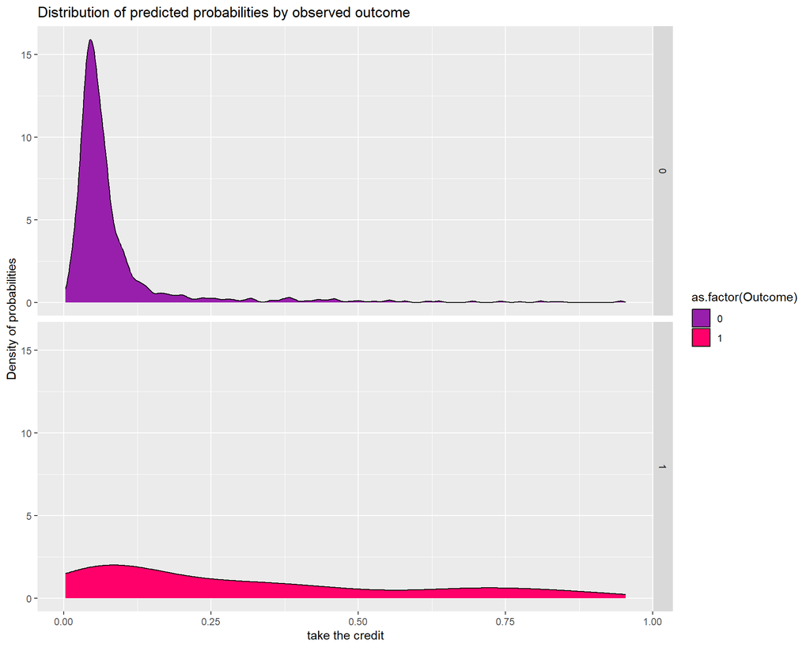

```r
ggplot(testProbs1, aes(x = Probs, fill = as.factor(Outcome))) +
  geom_density() +
  facet_grid(Outcome ~ .) +
  scale_fill_manual(values = palette2) +
  labs(x = "take the credit", y = "Density of probabilities",
       title = "Distribution of predicted probabilities by observed outcome") +
  theme(strip.text.x = element_text(size = 18))
```

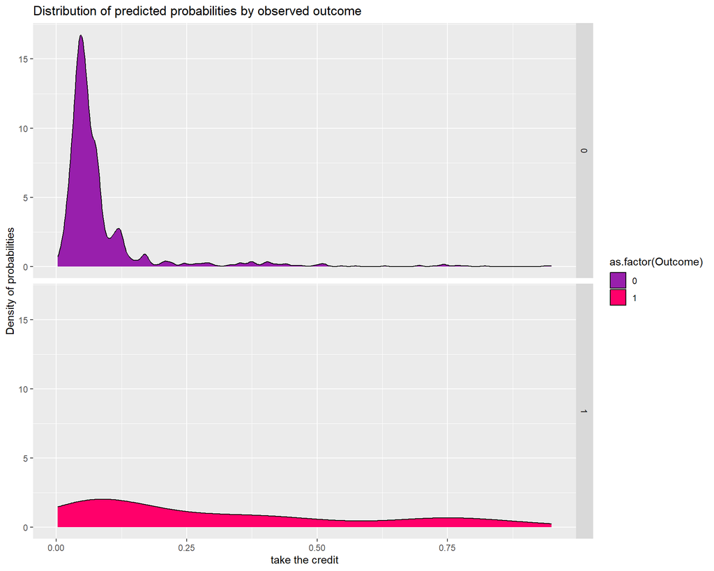

```r
        #legend.position = "none")

ggplot(testProbs2, aes(x = Probs, fill = as.factor(Outcome))) +
  geom_density() +
  facet_grid(Outcome ~ .) +
  scale_fill_manual(values = palette2) +
  labs(x = "take the credit", y = "Density of probabilities",
       title = "Distribution of predicted probabilities by observed outcome") +
  theme(strip.text.x = element_text(size = 18))
```

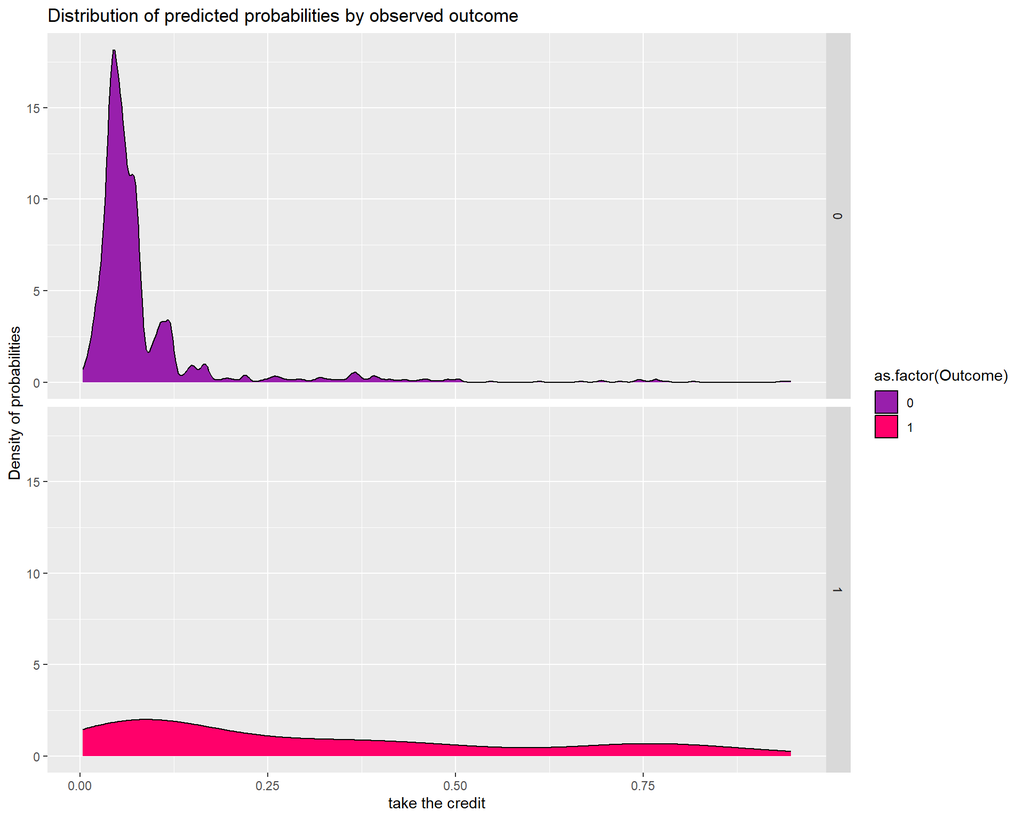

```r
ggplot(testProbs3, aes(x = Probs, fill = as.factor(Outcome))) +
  geom_density() +
  facet_grid(Outcome ~ .) +
  scale_fill_manual(values = palette2) +
  labs(x = "take the credit", y = "Density of probabilities",
       title = "Distribution of predicted probabilities by observed outcome") +
  theme(strip.text.x = element_text(size = 18))
```

## Confusion Matrix

*True Positive - Predicted correctly homeowner would enter credit program; allocated the marketing resources, and 25% ultimately achieved the credit.*

*True Negative - Predicted correctly homeowner would not enter the credit program, no marketing resources were allocated, and no credit was allocated.*

*False Positive - Predicted incorrectly homeowner would enter the credit program; allocated marketing resources; no credit allocated.*

*False Negative - We predicted that a homeowner would not enter the credit program but they did. These are likely homeowners who signed up for reasons unrelated to the marketing campaign. Thus, we ‘0 out’ this category, assuming the cost/benefit of this is $0.*

## ROC Curve

Furthermore, the ROC curve gives more insights into the models’ goodness of fit.By The goal is to maximum the area under the curve,which shows that the model is better. By comparison, model 3 has the largest area under curve of 0.786, while model 2 has 0.784 and model 1 has 0.778. As such, model 3 performs best in this situation.

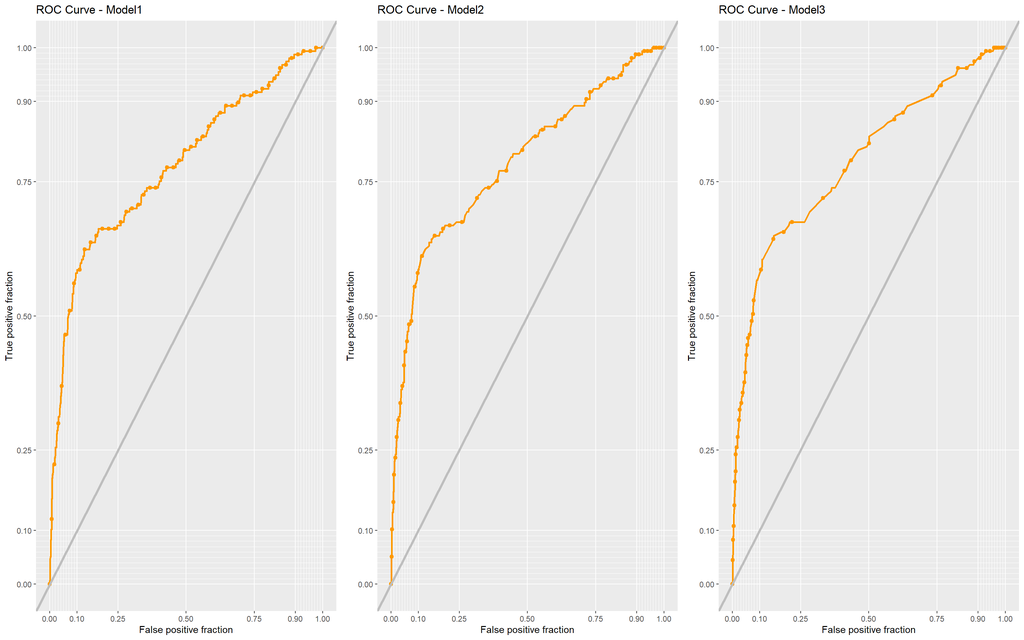

```r
area1 <- auc(testProbs1$Outcome, testProbs1$Probs)
roc1 <- ggplot(testProbs1, aes(d = as.numeric(Outcome), m = Probs)) +
  geom_roc(n.cuts = 50, labels = FALSE, colour = "#FE9900") +
  style_roc(theme = theme_grey) +
  geom_abline(slope = 1, intercept = 0, size = 1.5, color = 'grey') +
  labs(title = "ROC Curve - Model1")

area2 <-auc(testProbs2$Outcome, testProbs2$Probs)
roc2 <- ggplot(testProbs2, aes(d = as.numeric(Outcome), m = Probs)) +
  geom_roc(n.cuts = 50, labels = FALSE, colour = "#FE9900") +
  style_roc(theme = theme_grey) +
  geom_abline(slope = 1, intercept = 0, size = 1.5, color = 'grey') +
  labs(title = "ROC Curve - Model2")

area3 <-auc(testProbs3$Outcome, testProbs3$Probs)
roc3 <- ggplot(testProbs3, aes(d = as.numeric(Outcome), m = Probs)) +
  geom_roc(n.cuts = 50, labels = FALSE, colour = "#FE9900") +
  style_roc(theme = theme_grey) +
  geom_abline(slope = 1, intercept = 0, size = 1.5, color = 'grey') +
  labs(title = "ROC Curve - Model3")

plot_grid(roc1, roc2, roc3, ncol =3)
```

```r
cat("\nModel 0 area under the curve: ", area1)
```

```
##
## Model 0 area under the curve:  0.7780282
```

```r
cat("\nModel 0 area under the curve: ", area2)
```

```
##
## Model 0 area under the curve:  0.7839409
```

```r
cat("\nModel 0 area under the curve: ", area3)
```

```
##
## Model 0 area under the curve:  0.7859466
```

# Cross validation

From the 100-fold cross validation,the ROC (AUC), Sensitivity and Specificity across this series of predicitons still look good. From the cross valiadation goodness of fit metrics, the goal is to have tighter distribution to its mean, showing its generalizability. As we can see, both model 1 and model 3 generalizes well with respect to specificity - the rate it correctly predicts not taking the credit(the true negatives). It does not generalize as well with respect to sensitivity - the rate it correctly predicts taking the credit(true positives).

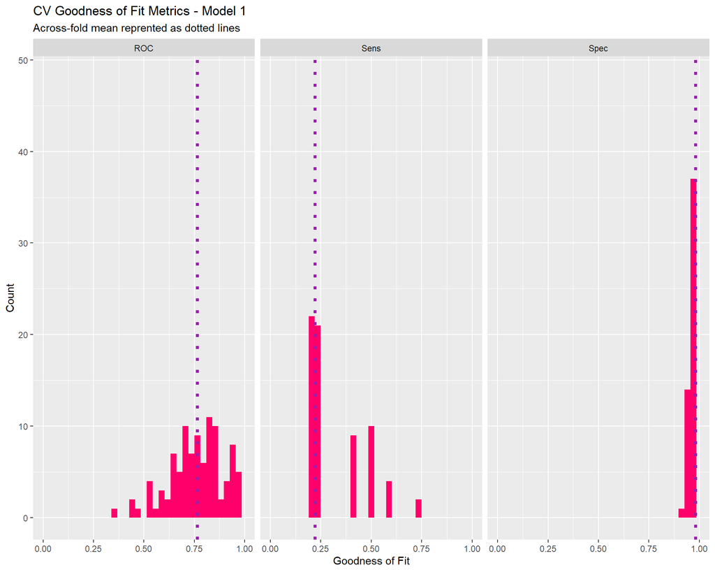

```r
dplyr::select(cvFit0$resample, -Resample) %>%
  gather(metric, value) %>%
  left_join(gather(cvFit0$results[2:4], metric, mean)) %>%
  ggplot(aes(value)) +
    geom_histogram(bins=35, fill = "#FF006A") +
    facet_wrap(~metric) +
    geom_vline(aes(xintercept = mean), colour = "#981FAC", linetype = 3, size = 1.5) +
    scale_x_continuous(limits = c(0, 1)) +
    labs(x="Goodness of Fit", y="Count", title="CV Goodness of Fit Metrics - Model 1",
         subtitle = "Across-fold mean reprented as dotted lines")
```

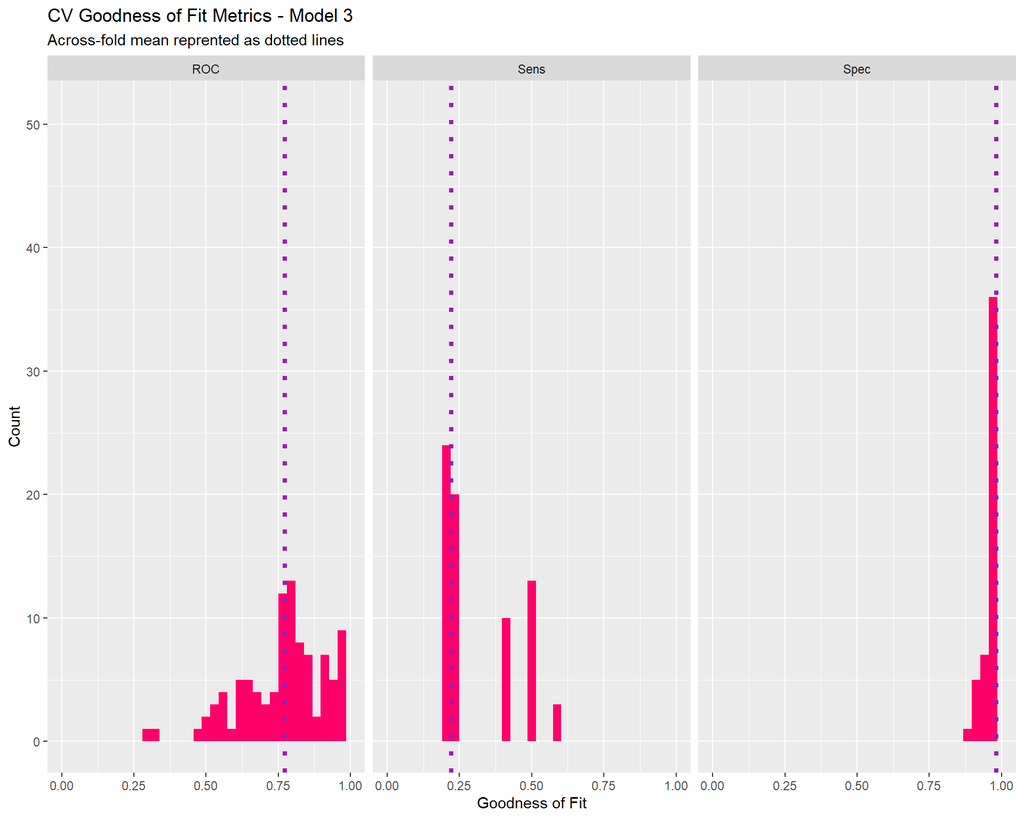

```r
dplyr::select(cvFit3$resample, -Resample) %>%
  gather(metric, value) %>%
  left_join(gather(cvFit3$results[2:4], metric, mean)) %>%
  ggplot(aes(value)) +
    geom_histogram(bins=35, fill = "#FF006A") +
    facet_wrap(~metric) +
    geom_vline(aes(xintercept = mean), colour = "#981FAC", linetype = 3, size = 1.5) +
    scale_x_continuous(limits = c(0, 1)) +
    labs(x="Goodness of Fit", y="Count", title="CV Goodness of Fit Metrics - Model 3",
         subtitle = "Across-fold mean reprented as dotted lines")
```

# Cost-Benefit Calculation

Because of higher sensitivity and accuracy, I chose the model 3 to predict. The overall goal is to target home owners who qualify for a home repair tax credit program.

The assumptions are: 25% of contacted eligible homeowners receive the credit, the remaining 75% that receive the marketing allocation and enter the program do not take the credit for various reasons.

**‘True Positive’: (-$2,850 + (-$5,000 + $10,000 + $56,000)* 25%) * Count**

**‘True Negative’: $0**

**‘False Positive’: -$2,850 * Count**

**‘False Negative’: $0**

## Cost-Benefit Table

```r
cost_benefit_table <-
   testProbs3 %>%
      count(predOutcome, Outcome) %>%
      summarize(True_Negative = sum(n[predOutcome==0 & Outcome==0]),
                True_Positive = sum(n[predOutcome==1 & Outcome==1]),
                False_Negative = sum(n[predOutcome==0 & Outcome==1]),
                False_Positive = sum(n[predOutcome==1 & Outcome==0])) %>%
       gather(Variable, Count) %>%
       mutate(Revenue =
               ifelse(Variable == "True_Negative", Count * 0,
               ifelse(Variable == "True_Positive",((0.25*(56000+10000-5000)-2850) * Count),
               ifelse(Variable == "False_Negative", Count * 0,
               ifelse(Variable == "False_Positive", (-2850) * Count, 0))))) %>%
    bind_cols(data.frame(Description = c(
              "We correctly predicted homeowner would enter the credit program; allocated the marketing resources, and 25% ultimately achieved the credit",
              "We correctly predicted homeowner would not enter the credit program, no marketing resources were allocated, and no credit was allocated",
              "We predicted that a homeowner would not enter the credit program but they did",
              "We predicted incorrectly homeowner would enter the credit program; allocated marketing resources; no credit allocated")))

kable(cost_benefit_table,
       caption = "Cost/Benefit Table") %>% kable_styling()
```

Cost/Benefit Table

[output not shown]

## Optimize Thresholds

The last step to tuning our model is to run it for each threshold value. I previously chose 0.5 as the line above which a prediction is classified as “taking the credit”. From the confusion matrices for each threshold, revenue is calculated for each confusion metric at each threshold. The goal is to choose the one that returns the most revenue.

From the Total_Count_of_Credits as a function of Threshold, we can find that as threshold changes, the % of confusion matrix changes as well.As the threshold increases, the number of false positives decreases, but the number of true negatives increases.

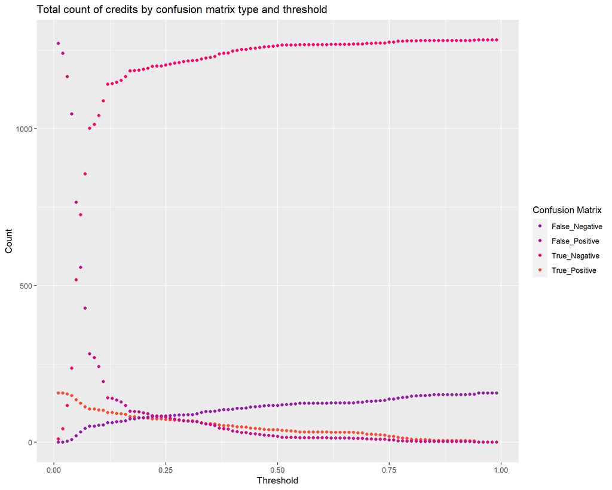

```r
whichThreshold <- iterateThresholds(testProbs3)

whichThreshold %>%
  ggplot(.,aes(Threshold, Count, colour = Variable)) +
  geom_point() +
  scale_colour_manual(values = palette5) +
  labs(title = "Total count of credits by confusion matrix type and threshold",
       y = "Count") +
  guides(colour=guide_legend(title = "Confusion Matrix"))
```

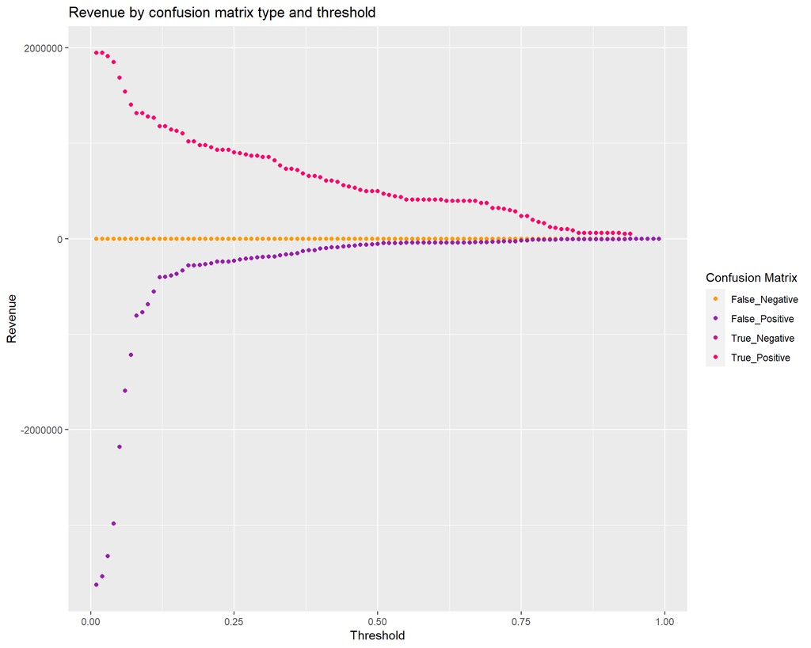

```r
whichThreshold %>%
  ggplot(.,aes(Threshold, Revenue, colour = Variable)) +
  geom_point() +
  scale_colour_manual(values = palette5[c(5, 1:3)]) +
  labs(title = "Revenue by confusion matrix type and threshold",
       y = "Revenue") +
  guides(colour=guide_legend(title = "Confusion Matrix"))
```

Moreover, the optimal threshold, which yields the highest revenue, is defined to be approximately 0.13.

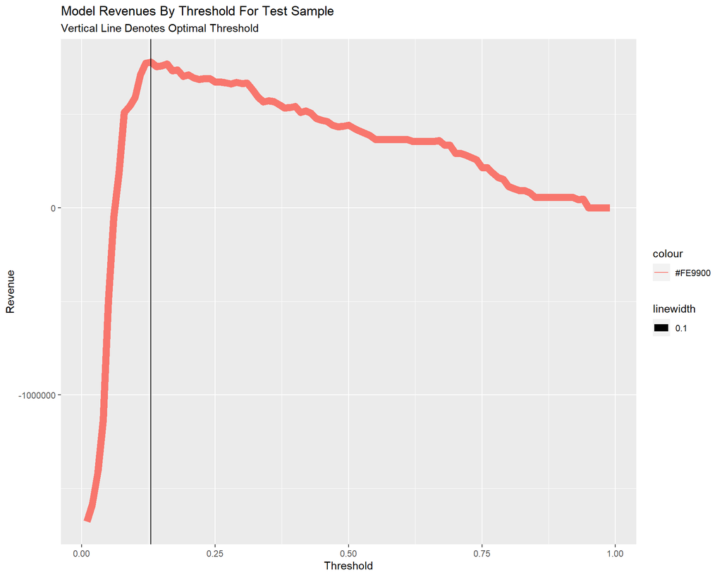

```r
whichThreshold <- iterateThresholds(testProbs3)

whichThreshold_revenue <-
whichThreshold %>%
    group_by(Threshold) %>%
    summarize(Revenue = sum(Revenue))

  ggplot(whichThreshold_revenue)+
  geom_line(aes(x = Threshold, y = Revenue, colour = "#FE9900",linewidth = 0.1))+
  geom_vline(xintercept =  pull(arrange(whichThreshold_revenue, -Revenue)[1,1]))+
    labs(title = "Model Revenues By Threshold For Test Sample",
         subtitle = "Vertical Line Denotes Optimal Threshold")
```

Total count of credits keep rising as threshold goes up.

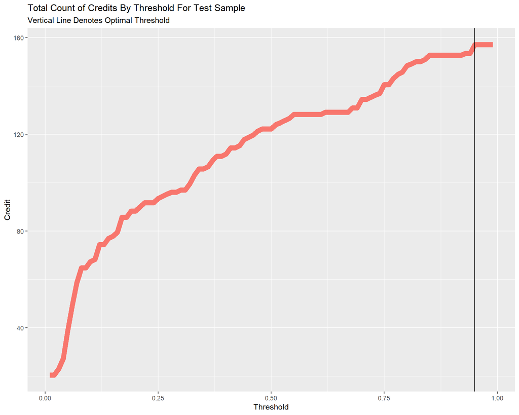

```r
whichThreshold_credit <-
whichThreshold %>%
  mutate(credit =  ifelse(Variable == "True_Positive", (Count * 0.13),
                             ifelse(Variable == "False_Negative", Count, 0))) %>%
  group_by(Threshold) %>%
  summarize(Credit = sum(credit))

  ggplot(whichThreshold_credit)+
  geom_line(aes(x = Threshold, y = Credit, colour = "#FE9900",linewidth = 0.1))+
  geom_vline(xintercept =  pull(arrange(whichThreshold_credit, -Credit)[1,1]))+
    labs(title = "Total Count of Credits By Threshold For Test Sample",
         subtitle = "Vertical Line Denotes Optimal Threshold")+
  theme(legend.position = "None")
```

Finally, the table below shows the contrast in revenue and count of credits between the optimal threshold(0.13) and the 0.50 threshold. The optimal threshold maximize revenue, bringing more benefits to the market. However, the number of home owners who take the credit is lower than the threshold of 0.50. In general, from a cost-benefit perspective, I would choose the optimal threshold for the model.

```r
threshold_table <- merge(whichThreshold_revenue, whichThreshold_credit, by = "Threshold")

final_table <- threshold_table %>%
                  slice(13, 50)

kable(final_table, caption = "Total Revenue and Total Count of Credits for Optimal Threshold and 0.5 Threshold") %>%
  kable_styling()
```

Total Revenue and Total Count of Credits for Optimal Threshold and 0.5 Threshold

| Threshold | Revenue | Credit |
| --- | --- | --- |
| 0.13 | 779000 | 74.35 |
| 0.50 | 441850 | 122.20 |

# Conclusion

In conclusion, I would not recommend deploying this model into production for several reasons. Firstly, the training dataset contains an extremely small number of records for people taking the credits, which significantly affects the model’s sensitivity, resulting in unsatisfactory predictive performance. This limitation can lead to reduced accuracy and a potential failure to target as many potential homeowners as desired. Although the model yields good revenue figures, its generalizability may be compromised. Furthermore, the feature engineering aspect of the model could benefit from enhancements once a better understanding of the variables is gained. I believe the model’s performance could be improved with the inclusion of additional variables.